# Market Impact and Order Book Events Analysis

## Event Classification

We need to classify the order book events into the following categories:

1. Market orders (MO): Buy and Sell
2. Limit orders (LO): Buy and Sell
3. Cancellations (CA): Buy and Sell

We'll use the event type ('etype') and side ('eside') columns to categorize these events.

```python
def classify_events(df):
    """Classify order book events into the 6 categories."""
    # Create a copy to avoid modifying the original dataframe
    df = df.copy()

    # Initialize event type columns
    df['event_type'] = 'Unknown'
    df['event_sign'] = 0

    # Market Orders (MO)
    mo_mask = df['etype'] == 'T'  # Trade events
    df.loc[mo_mask & (df['eside'] == 'S'), 'event_type'] = 'MO_buy'  # Buy market orders
    df.loc[mo_mask & (df['eside'] == 'B'), 'event_type'] = 'MO_sell'  # Sell market orders

    # Limit Orders (LO)
    lo_mask = df['etype'] == 'A'  # Add events
    df.loc[lo_mask & (df['eside'] == 'B'), 'event_type'] = 'LO_buy'  # Buy limit orders
    df.loc[lo_mask & (df['eside'] == 'S'), 'event_type'] = 'LO_sell'  # Sell limit orders

    # Cancellations (CA)
    ca_mask = df['etype'] == 'D'  # Delete events
    df.loc[ca_mask & (df['eside'] == 'B'), 'event_type'] = 'CA_buy'  # Buy cancellations
    df.loc[ca_mask & (df['eside'] == 'S'), 'event_type'] = 'CA_sell'  # Sell cancellations

    # Also consider 'C' (Change) events as cancellations
    c_mask = df['etype'] == 'C'  # Change events
    df.loc[c_mask & (df['eside'] == 'B'), 'event_type'] = 'CA_buy'  # Buy cancellations
    df.loc[c_mask & (df['eside'] == 'S'), 'event_type'] = 'CA_sell'  # Sell cancellations

    # Assign signs to events (+1 for buy, -1 for sell)
    df.loc[df['event_type'].str.contains('buy'), 'event_sign'] = 1
    df.loc[df['event_type'].str.contains('sell'), 'event_sign'] = -1
    # It is the contrary for cancellations
    df.loc[df['event_type'].str.contains('CA'), 'event_sign'] = df.loc[df['event_type'].str.contains('CA'), 'event_sign'] * (-1)

    # Create a simplified event type without buy/sell distinction
    df['event_category'] = df['event_type'].str.split('_').str[0]

    # Create a side indicator (1 for buy, -1 for sell)
    df['side'] = 0
    df.loc[df['eside'] == 'B', 'side'] = 1
    df.loc[df['eside'] == 'S', 'side'] = -1

    return df

def classify_all_the_days(dict_data):
    """
    Function to classify events for all days in the dictionary.
    Parameters:
    dict_data : dict
        Dictionary containing DataFrames for each day.
    Returns:
    dict
        Dictionary with classified DataFrames for each day.
    """
    classified_dict = {}
    for key, df in dict_data.items():
        classified_dict[key] = classify_events(df)
    return classified_dict
```

```python
# Classify events for all days in the dictionaries
classified_BNPP = classify_all_the_days(dict_BNPP)
classified_SG = classify_all_the_days(dict_SG)
# Check the classification for a specific day
classified_BNPP['20170118'].head(10)
```

| ets | etype | eprice | eqty | eside | bp0 | bq0 | ap0 | aq0 | mid_price | weighted_mid_price | log_mid_price | event_type | event_sign | event_category | side |
| --- | --- | --- | --- | --- | --- | --- | --- | --- | --- | --- | --- | --- | --- | --- | --- |
| 2017-01-18 09:00:14.085766 | A | 60600 | 39 | S | 60570 | 2051 | 60600 | 39 | 60585.0 | 60599.440191 | 11.011803 | LO_sell | -1 | LO | -1 |
| 2017-01-18 09:01:00.012238 | A | 60150 | 19667 | B | 60610 | 213 | 60630 | 440 | 60620.0 | 60616.523737 | 11.012380 | LO_buy | 1 | LO | 1 |
| 2017-01-18 09:01:00.012248 | A | 61080 | 19667 | S | 60610 | 213 | 60630 | 440 | 60620.0 | 60616.523737 | 11.012380 | LO_sell | -1 | LO | -1 |
| 2017-01-18 09:01:00.109735 | A | 60610 | 213 | S | 60610 | 213 | 60630 | 440 | 60620.0 | 60616.523737 | 11.012380 | LO_sell | -1 | LO | -1 |
| 2017-01-18 09:01:00.109738 | T | 60610 | 96 | B | 60610 | 117 | 60630 | 440 | 60620.0 | 60614.201077 | 11.012380 | MO_sell | -1 | MO | 1 |
| 2017-01-18 09:01:00.109745 | T | 60610 | 117 | B | 60580 | 131 | 60630 | 440 | 60605.0 | 60591.471103 | 11.012133 | MO_sell | -1 | MO | 1 |
| 2017-01-18 09:01:00.109950 | A | 60620 | 124 | S | 60580 | 131 | 60620 | 124 | 60600.0 | 60600.549020 | 11.012050 | LO_sell | -1 | LO | -1 |
| 2017-01-18 09:01:00.109961 | C | 60470 | 1650 | B | 60580 | 131 | 60620 | 124 | 60600.0 | 60600.549020 | 11.012050 | CA_buy | -1 | CA | 1 |
| 2017-01-18 09:01:00.110132 | A | 60650 | 268 | S | 60580 | 131 | 60620 | 124 | 60600.0 | 60600.549020 | 11.012050 | LO_sell | -1 | LO | -1 |
| 2017-01-18 09:01:00.110629 | C | 60620 | 124 | S | 60580 | 131 | 60630 | 440 | 60605.0 | 60591.471103 | 11.012133 | CA_sell | 1 | CA | -1 |

## 1. Sign and Side Autocorrelation Functions

We'll calculate and plot the sign autocorrelation function ⟨ϵt,ϵt+ℓ⟩ and side autocorrelation function ⟨st,st+ℓ⟩, where ϵt is the sign of the event at time t and st is the side (buy/sell) of the event at time t. We'll use logarithmically spaced lags for efficiency.

#### Autocorrelation function

```python
def autocorrelation(df: pd.DataFrame, lags, column: str = 'event_sign'):
    """
    Function to compute autocorrelation of the column.
    Parameters:
    df : DataFrame
        The input DataFrame containing event data.
    lags : int or list
        The number of lags for autocorrelation.
    Returns:
    float or list
        The autocorrelation value or values.
    """
    if isinstance(lags, list):
        return [float(df[column].autocorr(lag=lag)) for lag in lags]
    elif isinstance(lags, int):
        return float(df[column].autocorr(lag=lags))
    else:
        raise ValueError("lags should be an int or a list of ints")
```

#### Define Logarithmically Spaced Lags

To efficiently analyze long-range correlations, we'll use logarithmically spaced lags instead of calculating all lags sequentially. This approach allows us to capture behavior across multiple time scales while significantly reducing computation time.

```python
Lags = [ int(1.6**i) for i in range(1, 26)]
```

#### Plotting the autocorrelation functions

```python
def plot_autocorrelation_all_days(dict_data: dict, lags: list, column: str = 'event_sign'):
    """
    Function to plot autocorrelation for all days in the dictionary.
    Parameters:
    dict_data : dict
        Dictionary containing DataFrames for each day.
    lags : list
        List of lags for autocorrelation.
    column : str
        The column name for which to compute autocorrelation.
    """
    fig, ax = plt.subplots()
    list_autocorr = []
    for key, df in dict_data.items():
        acf_values = autocorrelation(df, lags, column)
        list_autocorr.append(acf_values)
        ax.plot(lags, acf_values, color='blue', label="Unique day", alpha=0.5, lw=0.5)

    # Compute mean and std of autocorrelation values
    mean_acf = np.mean(list_autocorr, axis=0)
    std_acf = np.std(list_autocorr, axis=0)
    ax.plot(lags, mean_acf, color='red', label='Mean ACF', lw=2)
    ax.fill_between(lags, mean_acf - std_acf, mean_acf + std_acf, color='red', alpha=0.2, label='Std ACF')
    ax.scatter(lags, mean_acf, color='red', s=50, zorder=5)
    ax.set_xticks(lags)
    ax.set_xticklabels(lags, rotation=45)
    ax.set_xlabel('Lags')
    ax.set_xscale('log')
    ax.set_ylabel('Autocorrelation')
    ax.axhline(0, color='black', lw=0.5, ls='--')
    ax.set_ylim(-0.1, 1)
    ax.set_title(f'Autocorrelation of {column} for all days')

    #unique labels
    handles, labels = ax.get_legend_handles_labels()
    unique_labels = dict(zip(labels, handles))
    ax.legend(unique_labels.values(), unique_labels.keys())
    plt.show()

def multiple_plot_autocorrelation(dict_data1:dict, dict_data2 : dict, lags: list,
                                  stock_names: list = ["BNP", "SG"], column: str = 'event_sign', figsize: tuple = (20, 5),
                                  ylim: tuple = (-0.1, 0.2), color: str = 'red', ylog: bool = False,
                                  power_law_fit: bool = False):
    """
    Function to plot autocorrelation for two dictionaries of DataFrames on 2 subplots.
    Parameters:
    dict_data1 : dict
        First dictionary containing DataFrames for each day.
    dict_data2 : dict
        Second dictionary containing DataFrames for each day.
    lags : list
        List of lags for autocorrelation.
    column : str
        The column name for which to compute autocorrelation.
    """
    fig, (ax1, ax2) = plt.subplots(1, 2, figsize=figsize)
    # Set the title for the entire figure
    title_column = column.replace('_', ' ').capitalize() # Capitalize the first letter of each wordlize
    fig.suptitle(f'{title_column} autocorrelation for different lags', fontsize=20)

    fig.subplots_adjust(wspace=3)
    list_autocorr1 = []
    list_autocorr2 = []

    # Compute autocorrelation for the first dictionary
    for key, df in dict_data1.items():
        acf_values = autocorrelation(df, lags, column)
        list_autocorr1.append(acf_values)
        ax1.plot(lags, acf_values, color='blue', label="Unique day", alpha=0.5, lw=0.5)

    # Compute mean and std of autocorrelation values for the first dictionary
    mean_acf1 = np.mean(list_autocorr1, axis=0)
    std_acf1 = np.std(list_autocorr1, axis=0)
    ax1.plot(lags, mean_acf1, color=color, label='Mean ACF', lw=2)
    ax1.fill_between(lags, mean_acf1 - std_acf1, mean_acf1 + std_acf1, color=color, alpha=0.2, label='Std ACF')
    ax1.scatter(lags, mean_acf1, color=color, s=50, zorder=5)
    ax1.set_xscale('log')
    if ylog:
        ax1.set_yscale('log')
    ax1.set_xticks(lags)
    ax1.set_xticklabels(lags, rotation=45)
    ax1.set_xlabel('Lags')
    ax1.set_ylabel('Autocorrelation')
    ax1.axhline(0, color='black', lw=0.5, ls='--')
    ax1.set_ylim(ylim)
    if power_law_fit:
        # Fit power law to autocorrelation
        def power_law(x, a, b):
            return a * (x ** b)
        # Fit power law to the mean autocorrelation values
        # Use only positive lags for fitting
        positive_lags = np.array(lags)[mean_acf1 > 0]
        positive_acf1 = mean_acf1[mean_acf1 > 0]
        # Fit the power law model to the data
        params1, _ = curve_fit(power_law, positive_lags, positive_acf1)
        ax1.plot(positive_lags, power_law(positive_lags, *params1), color='purple', linestyle = '--', label=f'Power Law Fit (beta = {params1[1]:.2f})', lw=2)
    #unique labels
    handles, labels = ax1.get_legend_handles_labels()
    unique_labels = dict(zip(labels, handles))
    ax1.legend(unique_labels.values(), unique_labels.keys())
    ax1.set_title(f'{stock_names[0]}')


    # Compute autocorrelation for the second dictionary
    for key, df in dict_data2.items():
        acf_values = autocorrelation(df, lags, column)
        list_autocorr2.append(acf_values)
        ax2.plot(lags, acf_values, color='blue', label="Unique day", alpha=0.5, lw=0.5)

    # Compute mean and std of autocorrelation values for the second dictionary
    mean_acf2 = np.mean(list_autocorr2, axis=0)
    std_acf2 = np.std(list_autocorr2, axis=0)
    ax2.plot(lags, mean_acf2, color=color, label='Mean ACF', lw=2)
    ax2.fill_between(lags, mean_acf2 - std_acf2, mean_acf2 + std_acf2, color=color, alpha=0.2, label='Std ACF')
    ax2.scatter(lags, mean_acf2, color=color, s=50, zorder=5)
    ax2.set_xscale('log')
    if ylog:
        ax2.set_yscale('log')
    ax2.set_xticks(lags)
    ax2.set_xticklabels(lags, rotation=45)
    ax2.set_xlabel('Lags')
    ax2.set_ylabel('Autocorrelation')
    ax2.axhline(0, color='black', lw=0.5, ls='--')
    ax2.set_ylim(ylim)
    if power_law_fit:
        # Fit power law to the mean autocorrelation values
        # Use only positive lags for fitting
        positive_lags = np.array(lags)[mean_acf2 > 0]
        positive_acf2 = mean_acf2[mean_acf2 > 0]
        # Fit the power law model to the data
        params2, _ = curve_fit(power_law, positive_lags, positive_acf2)
        ax2.plot(positive_lags, power_law(positive_lags, *params2), color='purple', linestyle = '--', label=f'Power Law Fit (beta = {params2[1]:.2f})', lw=2)
    #unique labels
    handles, labels = ax2.get_legend_handles_labels()
    unique_labels = dict(zip(labels, handles))
    ax2.legend(unique_labels.values(), unique_labels.keys())
    ax2.set_title(f'{stock_names[1]}')

    plt.tight_layout()
    plt.show()
```

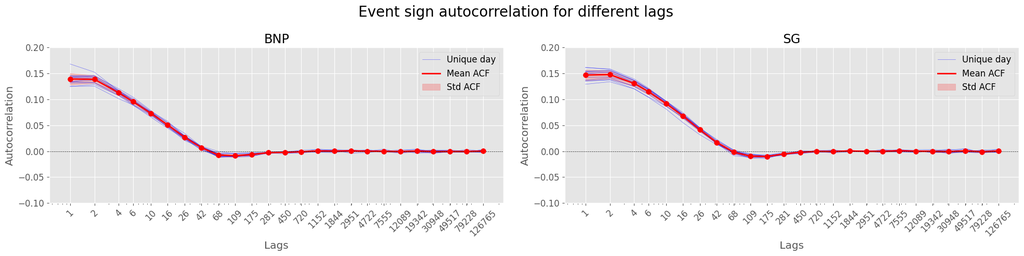

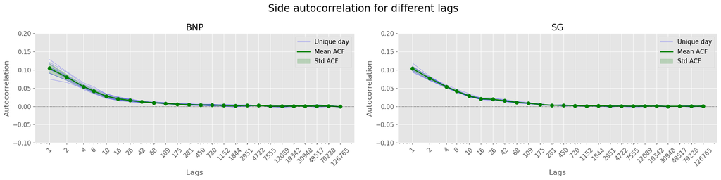

```python
multiple_plot_autocorrelation(classified_BNPP, classified_SG, Lags, column='event_sign')
multiple_plot_autocorrelation(classified_BNPP, classified_SG, Lags, column='side', color='green')
```

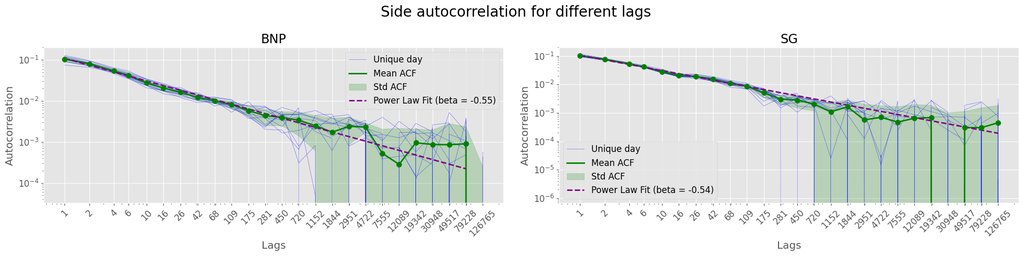

```python
multiple_plot_autocorrelation(classified_BNPP, classified_SG, Lags, column='side', color='green', ylog=True, power_law_fit=True)
```

## 2. Empirical Response Functions (took ~10min)

Now we'll calculate and plot the empirical response functions Rπ(ℓ) for each of the 6 types of events π. The response function measures the average price change ℓ events after an event of type π. We'll use logarithmically spaced lags for efficiency.

```python
df = classified_BNPP['20170118']
df.head(10)
```

| ets | etype | eprice | eqty | eside | bp0 | bq0 | ap0 | aq0 | mid_price | weighted_mid_price | log_mid_price | event_type | event_sign | event_category | side |
| --- | --- | --- | --- | --- | --- | --- | --- | --- | --- | --- | --- | --- | --- | --- | --- |
| 2017-01-18 09:00:14.085766 | A | 60600 | 39 | S | 60570 | 2051 | 60600 | 39 | 60585.0 | 60599.440191 | 11.011803 | LO_sell | -1 | LO | -1 |
| 2017-01-18 09:01:00.012238 | A | 60150 | 19667 | B | 60610 | 213 | 60630 | 440 | 60620.0 | 60616.523737 | 11.012380 | LO_buy | 1 | LO | 1 |
| 2017-01-18 09:01:00.012248 | A | 61080 | 19667 | S | 60610 | 213 | 60630 | 440 | 60620.0 | 60616.523737 | 11.012380 | LO_sell | -1 | LO | -1 |
| 2017-01-18 09:01:00.109735 | A | 60610 | 213 | S | 60610 | 213 | 60630 | 440 | 60620.0 | 60616.523737 | 11.012380 | LO_sell | -1 | LO | -1 |
| 2017-01-18 09:01:00.109738 | T | 60610 | 96 | B | 60610 | 117 | 60630 | 440 | 60620.0 | 60614.201077 | 11.012380 | MO_sell | -1 | MO | 1 |
| 2017-01-18 09:01:00.109745 | T | 60610 | 117 | B | 60580 | 131 | 60630 | 440 | 60605.0 | 60591.471103 | 11.012133 | MO_sell | -1 | MO | 1 |
| 2017-01-18 09:01:00.109950 | A | 60620 | 124 | S | 60580 | 131 | 60620 | 124 | 60600.0 | 60600.549020 | 11.012050 | LO_sell | -1 | LO | -1 |
| 2017-01-18 09:01:00.109961 | C | 60470 | 1650 | B | 60580 | 131 | 60620 | 124 | 60600.0 | 60600.549020 | 11.012050 | CA_buy | -1 | CA | 1 |
| 2017-01-18 09:01:00.110132 | A | 60650 | 268 | S | 60580 | 131 | 60620 | 124 | 60600.0 | 60600.549020 | 11.012050 | LO_sell | -1 | LO | -1 |
| 2017-01-18 09:01:00.110629 | C | 60620 | 124 | S | 60580 | 131 | 60630 | 440 | 60605.0 | 60591.471103 | 11.012133 | CA_sell | 1 | CA | -1 |

```python
def response_at_eventType(df: pd.DataFrame, lag: int, event_type: str, price_column: str):
    df2 = df.copy()
    # reset index to get the original index
    df2.reset_index(inplace=True)
    indices_events = np.array(df2[df2['event_type'] == event_type].index)
    indices_events_plus_lag = indices_events + lag
    # Get the indices of the events that are within the bounds of the DataFrame
    valid_indices_events = indices_events[indices_events_plus_lag < len(df2)]
    valid_indices_events_plus_lag = indices_events_plus_lag[indices_events_plus_lag < len(df2)]
    # Compute the mean response and std for the event type at the specified lag
    mean_response = float( np.mean( (df2.loc[valid_indices_events_plus_lag, price_column].values - df2.loc[valid_indices_events, price_column].values) * (df2.loc[valid_indices_events, 'event_sign'].values)))
    std_response = float( np.std( (df2.loc[valid_indices_events_plus_lag, price_column].values - df2.loc[valid_indices_events, price_column].values) * (df2.loc[valid_indices_events, 'event_sign'].values) ) )
    return mean_response, std_response

def response_at_eventType_different_lags(df: pd.DataFrame, lags: list, event_type: str = 'MO_buy', price_column: str = 'mid_price'):
    """
    Function to compute the response at different lags for a specific event type.
    Parameters:
    df : DataFrame
        The input DataFrame containing event data.
    lags : list
        List of lags for which to compute the response.
    event_type : str
        The event type for which to compute the response.
    price_column : str
        The column name for the price data.
    Returns:
    mean_responses : list
        List of mean responses for each lag.
    std_responses : list
        List of std responses for each lag.
    """
    mean_responses = []
    std_responses = []
    # Compute the mean and std response for each lag
    for lag in lags:
        mean_response, std_response = response_at_eventType(df=df, lag=lag, event_type=event_type, price_column=price_column)
        mean_responses.append(mean_response)
        std_responses.append(std_response)
    return mean_responses, std_responses
```

```python
#plot response at event type for different lags
def plot_response_at_eventType_different_lags(dict_data1 : dict, dict_data2 : dict, lags: list,
                                            event_type: str = 'MO_buy', price_column: str = 'mid_price',
                                            stock_names: list = ["BNP", "SG"], figsize: tuple = (20, 5),
                                            color: str = 'green', xlog: bool = True, ylim: tuple = (-20, 40)) :
    """
    Function to plot the response at different lags for a specific event type.
    Parameters:
    df : DataFrame
        The input DataFrame containing event data.
    lags : list
        List of lags for which to compute the response.
    event_type : str
        The event type for which to compute the response.
    price_column : str
        The column name for the price data.
    color : str
        Color for the plot line.
    title : str
        Title for the plot.
    ylim : tuple
        Limits for the y-axis.
    """
    responses1 = []
    for key, df in dict_data1.items():
        mean_responses, _ = response_at_eventType_different_lags(df=df, lags=lags, event_type=event_type, price_column=price_column)
        responses1.append(mean_responses)

    responses2 = []
    for key, df in dict_data2.items():
        mean_responses, _ = response_at_eventType_different_lags(df=df, lags=lags, event_type=event_type, price_column=price_column)
        responses2.append(mean_responses)


    fig, (ax1, ax2) = plt.subplots( 1, 2,figsize=figsize)
    fig.suptitle(f'Reponse at {event_type}', fontsize=20)
    fig.subplots_adjust(wspace=0.5)
    # Plot for the first dictionary
    for mean_responses in responses1:
        ax1.plot(lags, mean_responses, color='blue', label='Unique day', alpha=0.5, lw=0.5)
    ax1.axhline(0, color='black', lw=0.5, ls='--')
    # compute mean
    mean_response = np.mean(responses1, axis=0)
    ax1.plot(lags, mean_response, color=color, label='Mean Response', lw=2)
    ax1.scatter(lags, mean_response, color=color, s=50, zorder=5)
    ax1.set_title(f'for {stock_names[0]}')
    ax1.set_xlabel('Lags')
    ax1.set_ylabel(price_column)
    if xlog:
        ax1.set_xscale('log')
    ax1.set_ylim(ylim)
    ax1.set_xticks(lags)
    ax1.set_xticklabels(lags, rotation=45)
    #unique labels
    handles, labels = ax1.get_legend_handles_labels()
    unique_labels = dict(zip(labels, handles))
    ax1.legend(unique_labels.values(), unique_labels.keys())


    for mean_responses in responses2:
        ax2.plot(lags, mean_responses, color='blue', label='Unique day', alpha=0.5, lw=0.5)
    ax2.axhline(0, color='black', lw=0.5, ls='--')
    # compute mean
    mean_response = np.mean(responses2, axis=0)
    ax2.plot(lags, mean_response, color=color, label='Mean Response', lw=2)
    ax2.scatter(lags, mean_response, color=color, s=50, zorder=5)
    ax2.set_title(f'for {stock_names[1]}')
    ax2.set_xlabel('Lags')
    ax2.set_ylabel(price_column)
    if xlog:
        ax2.set_xscale('log')
    ax2.set_ylim(ylim)
    ax2.set_xticks(lags)
    ax2.set_xticklabels(lags, rotation=45)
    #unique labels
    handles, labels = ax2.get_legend_handles_labels()
    unique_labels = dict(zip(labels, handles))
    ax2.legend(unique_labels.values(), unique_labels.keys())

    plt.tight_layout()
    plt.show()
```